# Week 7

Jeremiah Lowhorn

2023-10-10

# Linear Models Continued

Remember our assumptions:

1 Since residuals are squared, the assumption follows that residuals are normally distributed

- Otherwise you will have influential points who weight the slope of the line!

2 More rows than columns

3 Linear relationship

4 Homoscedasticity of residuals or equal variance

- No pattern in the residuals

5 No auto-correlation of residuals

6 No multivariate multicollinearity (not needed for this example)

## Train Test Split

```r
data <- mtcars
data <- data[row.names(data) != "Toyota Corolla", , drop = FALSE]
sample <- sample.int(n = nrow(data), size = floor(.8*nrow(data)), replace = F)
train <- data[sample, ]
test  <- data[-sample, ]
```

### Testing for Autocorrelation

[Autocorrelation Link](https://towardsdatascience.com/understanding-autocorrelation-ddce4f0a9fda)

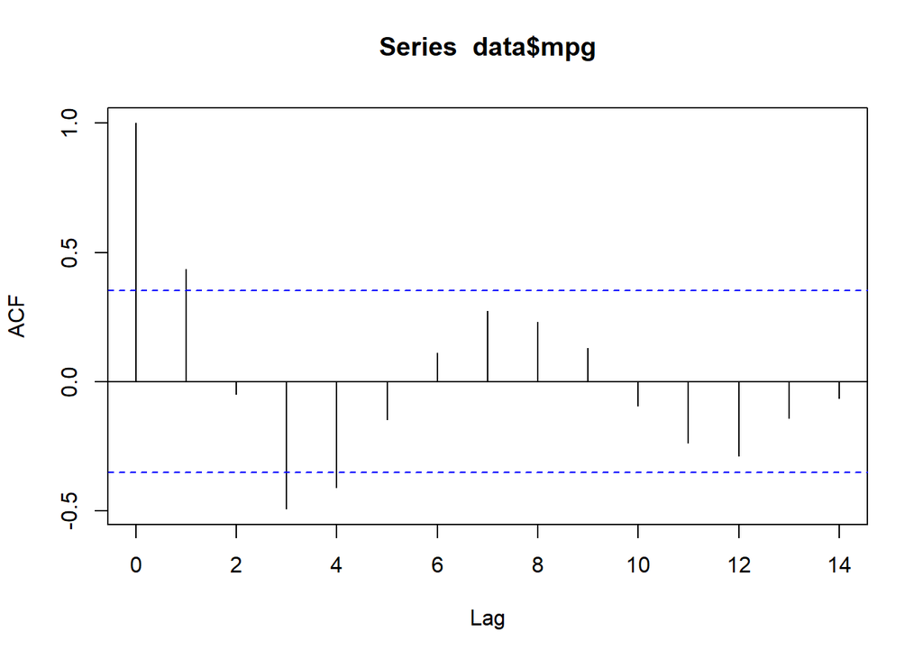

```r
acf(data$mpg)
```

### Testing for Multicollinearity

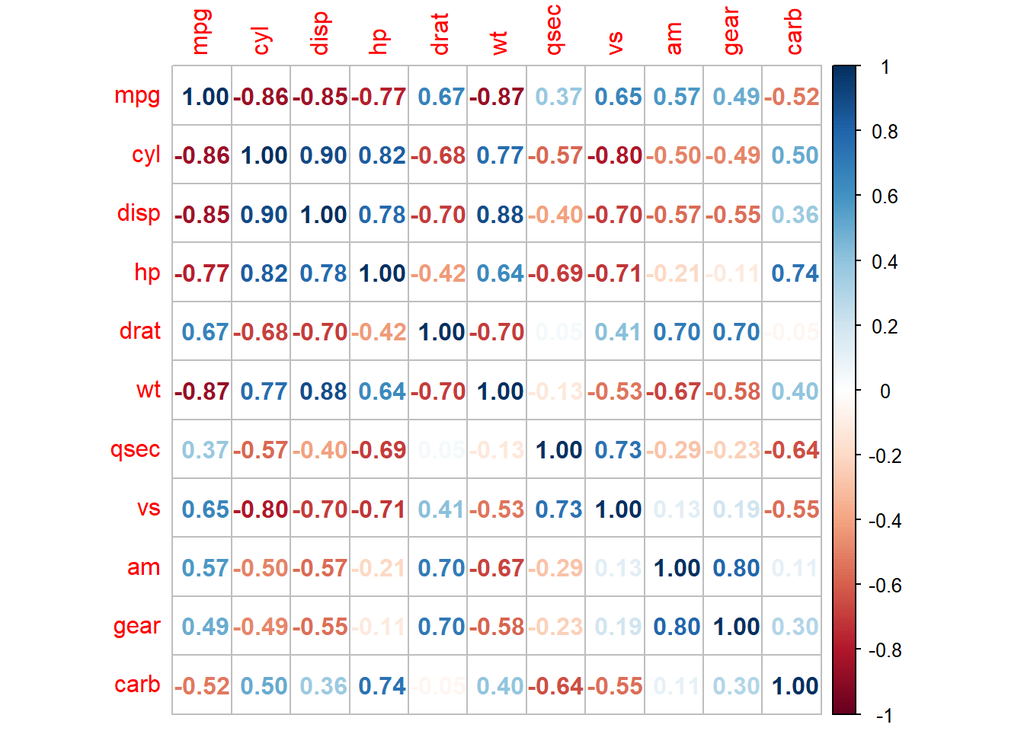

```r
corrplot(cor(data),method='number')
```

### The Everything Model

```r
mod <- lm(mpg~., train)
summary(mod)
```

```
##
## Call:
## lm(formula = mpg ~ ., data = train)
##
## Residuals:
##     Min      1Q  Median      3Q     Max
## -2.1954 -1.2729 -0.2127  1.2039  3.0516
##
## Coefficients:
##             Estimate Std. Error t value Pr(>|t|)
## (Intercept) 42.91778   19.12316   2.244   0.0429 *
## cyl         -2.20086    1.18985  -1.850   0.0872 .
## disp         0.03301    0.01923   1.717   0.1098
## hp          -0.02971    0.02478  -1.199   0.2521
## drat        -0.06726    1.53026  -0.044   0.9656
## wt          -4.38511    2.02626  -2.164   0.0497 *
## qsec         0.06738    0.68921   0.098   0.9236
## vs          -0.30335    1.87816  -0.162   0.8742
## am          -0.62224    2.21855  -0.280   0.7835
## gear        -0.24339    1.56707  -0.155   0.8790
## carb         0.67167    0.90501   0.742   0.4712
## ---
## Signif. codes:  0 '***' 0.001 '**' 0.01 '*' 0.05 '.' 0.1 ' ' 1
##
## Residual standard error: 2.18 on 13 degrees of freedom
## Multiple R-squared:  0.884,  Adjusted R-squared:  0.7948
## F-statistic: 9.908 on 10 and 13 DF,  p-value: 0.000144
```

### Variance Inflation Factor

[figure not shown]

```r
#load the car library
library(car)
#calculate the VIF for each predictor variable in the model
vif(mod)
```

```
##       cyl      disp        hp      drat        wt      qsec        vs        am
## 21.245514 21.709683  9.614291  3.432070 14.495988  7.007737  4.328804  6.040045
##      gear      carb
##  6.457633  6.289139
```

### Base Model Plots (Residual Analysis)

[QQ Plots Explained](https://library.virginia.edu/data/articles/understanding-q-q-plots#:~:text=The%20QQ%20plot%2C%20or%20quantile,as%20a%20normal%20or%20exponential.)

#### QQ Plot

The QQ plot, or quantile-quantile plot, is a graphical tool to help us assess if a set of data plausibly came from some theoretical distribution such as a normal or exponential. For example, if we run a statistical analysis that assumes our residuals are normally distributed, we can use a normal QQ plot to check that assumption. It’s just a visual check, not an air-tight proof, so it is somewhat subjective. But it allows us to see at-a-glance if our assumption is plausible, and if not, how the assumption is violated and what data points contribute to the violation.

#### Scale Location Plot

The Scale-Location plot helps evaluate the assumption of homoscedasticity, or equal variance of residuals. This plot displays the spread (or scatter) of the square-rooted standardized residuals against the fitted values.

#### Residuals vs Leverage Plot

A residuals vs. leverage plot is a type of diagnostic plot that allows us to identify influential observations in a regression model.

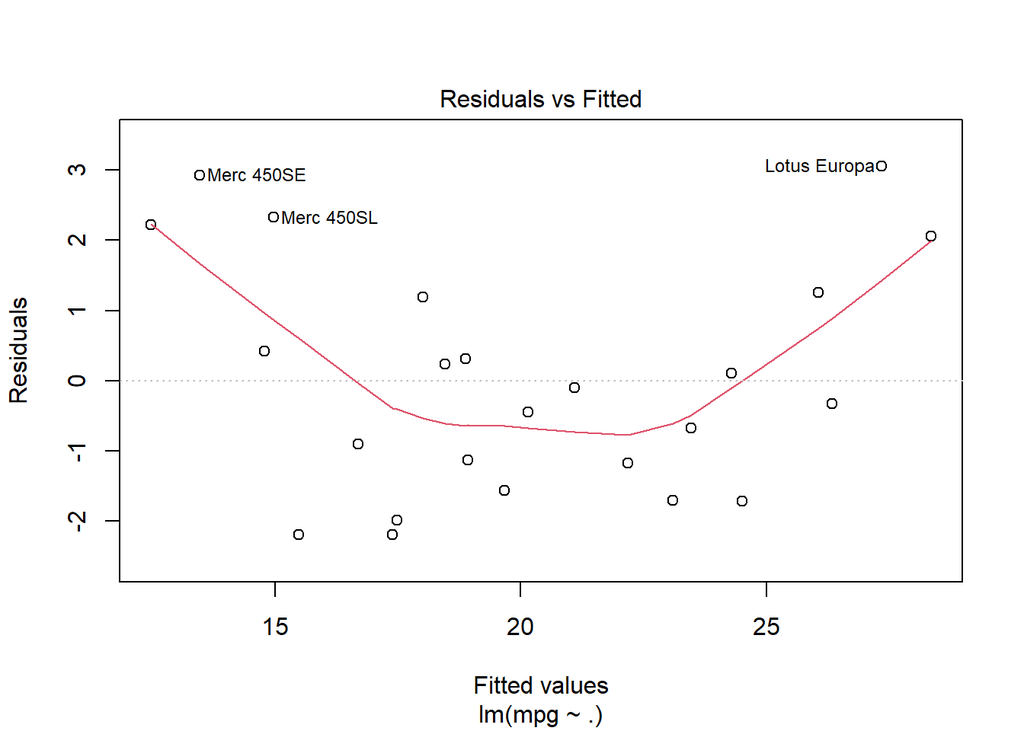

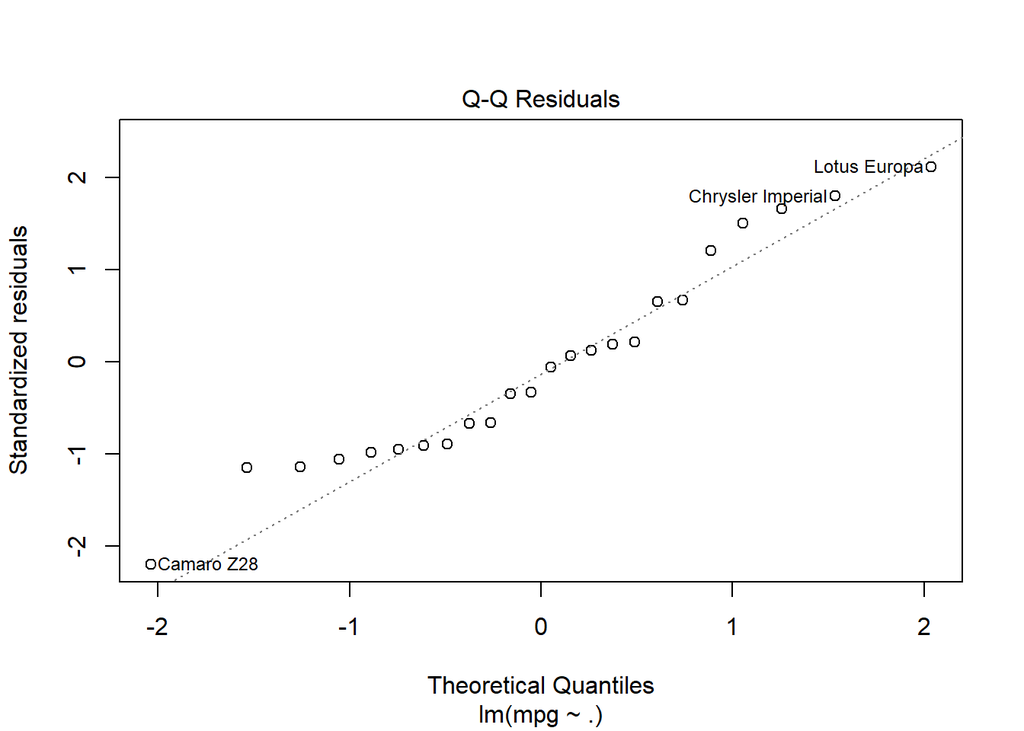

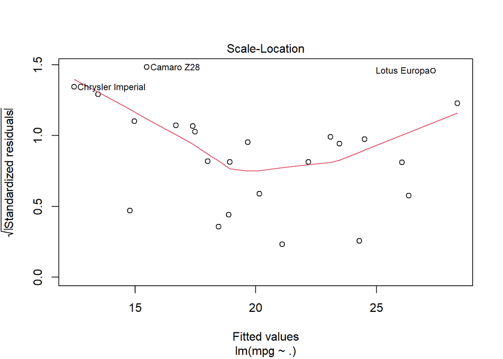

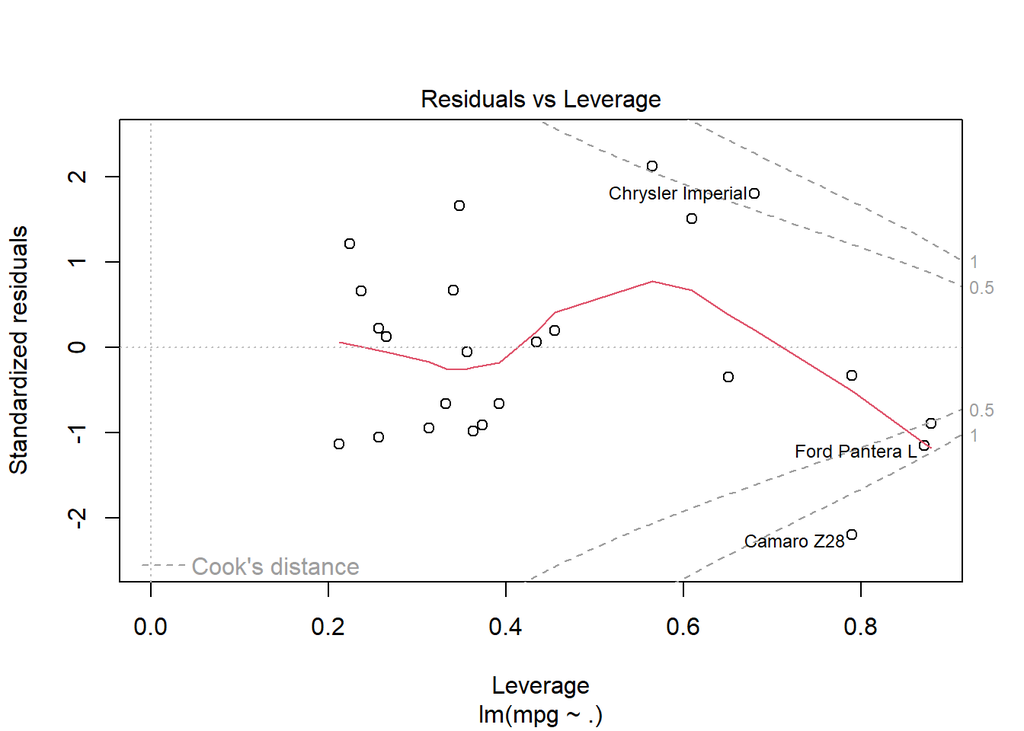

```r
plot(mod)
```

#### Training Error

```r
train_preds <- predict(mod,train)
train_resid <- train$mpg - train_preds

mse <- mse(train$mpg , train_preds)
mae <- mae(train$mpg, train_preds)
mape <- mape(train$mpg, train_preds)

print(paste("Mean Squared Error is: ", round(mse,4)))
```

```
## [1] "Mean Squared Error is:  2.5748"
```

```r
print(paste("Mean Absolute Error is: ", round(mae,4)))
```

```
## [1] "Mean Absolute Error is:  1.3409"
```

```r
print(paste0("Mean Absolute Percentage Error is: ", round(mape*100,2), '%'))
```

```
## [1] "Mean Absolute Percentage Error is: 7.18%"
```

#### Autocorrelation in Residuals

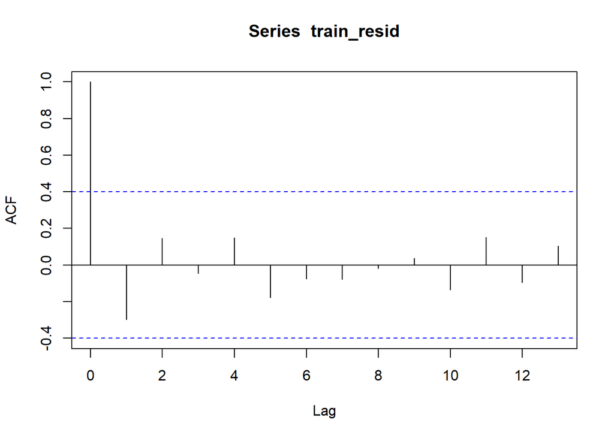

```r
acf(train_resid)
```

#### Test Error

```r
test_preds <- predict(mod,test)
resid <- test$mpg - test_preds

mse <- mse(test$mpg , test_preds)
mae <- mae(test$mpg, test_preds)
mape <- mape(test$mpg, test_preds)

print(paste("Mean Squared Error is: ", round(mse,4)))
```

```
## [1] "Mean Squared Error is:  15.0447"
```

```r
print(paste("Mean Absolute Error is: ", round(mae,4)))
```

```
## [1] "Mean Absolute Error is:  3.2001"
```

```r
print(paste0("Mean Absolute Percentage Error is: ", round(mape*100,2), '%'))
```

```
## [1] "Mean Absolute Percentage Error is: 19.58%"
```

### Ideal Model

```r
mod2 <- lm(mpg ~ wt + qsec, train)
summary(mod2)
```

```
##
## Call:
## lm(formula = mpg ~ wt + qsec, data = train)
##
## Residuals:
##     Min      1Q  Median      3Q     Max
## -3.2372 -1.8596 -0.2748  1.1398  5.2318
##
## Coefficients:
##             Estimate Std. Error t value Pr(>|t|)
## (Intercept)  22.2781     5.1930   4.290 0.000325 ***
## wt           -4.7410     0.5505  -8.612 2.47e-08 ***
## qsec          0.7193     0.2693   2.671 0.014296 *
## ---
## Signif. codes:  0 '***' 0.001 '**' 0.01 '*' 0.05 '.' 0.1 ' ' 1
##
## Residual standard error: 2.252 on 21 degrees of freedom
## Multiple R-squared:  0.8001, Adjusted R-squared:  0.7811
## F-statistic: 42.04 on 2 and 21 DF,  p-value: 4.546e-08
```

#### Base Model Plots (Residual Analysis)

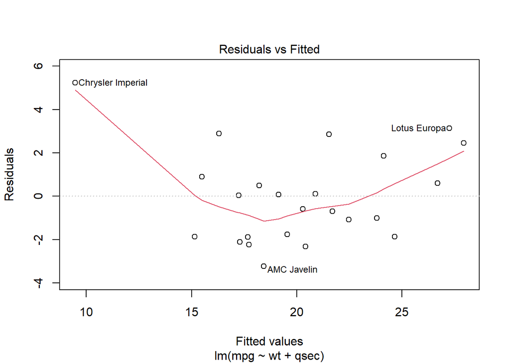

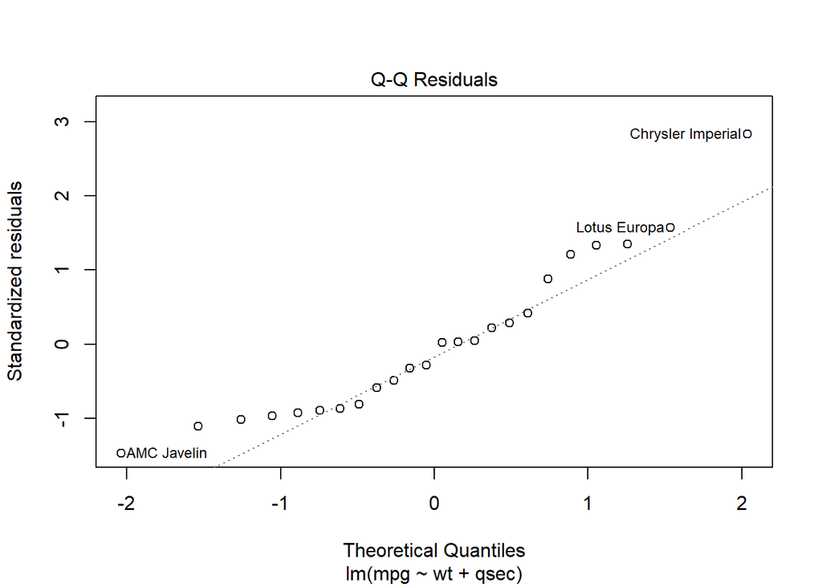

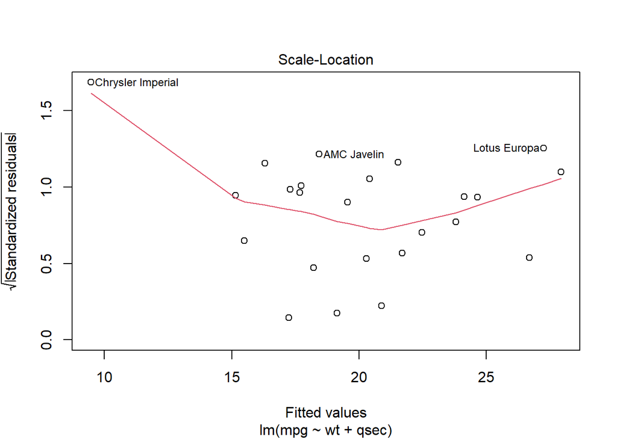

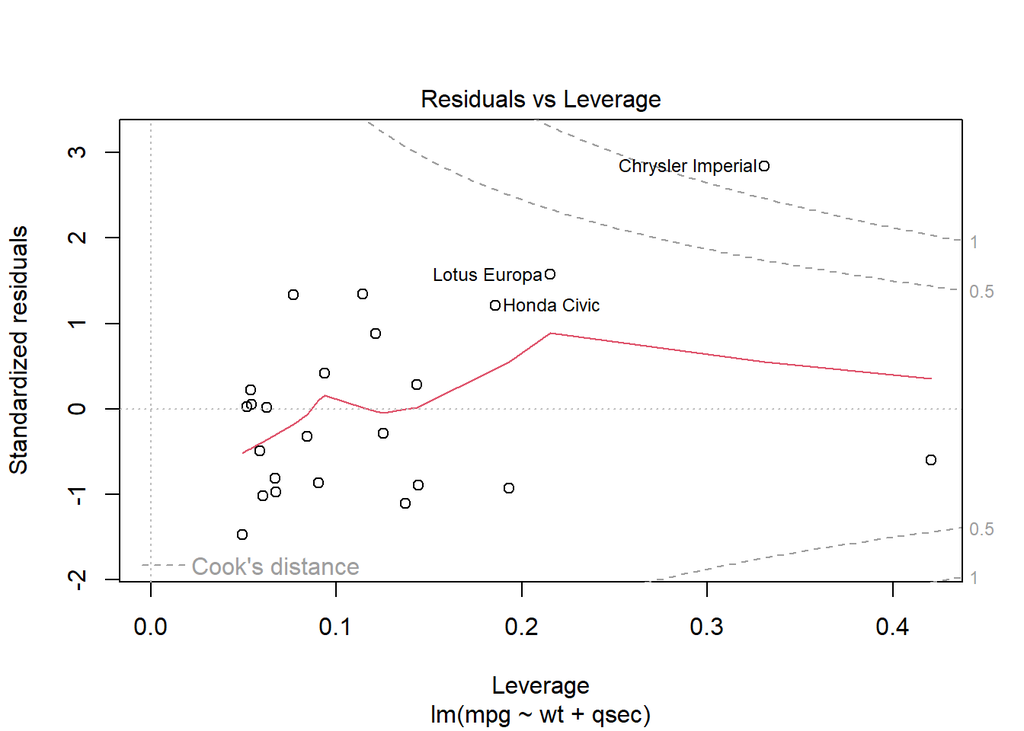

```r
plot(mod2)
```

#### Training Error

```r
train_preds <- predict(mod2,train)
train_resid <- train$mpg - train_preds

mse <- mse(train$mpg , train_preds)
mae <- mae(train$mpg, train_preds)
mape <- mape(train$mpg, train_preds)

print(paste("Mean Squared Error is: ", round(mse,4)))
```

```
## [1] "Mean Squared Error is:  4.4368"
```

```r
print(paste("Mean Absolute Error is: ", round(mae,4)))
```

```
## [1] "Mean Absolute Error is:  1.7199"
```

```r
print(paste0("Mean Absolute Percentage Error is: ", round(mape*100,2), '%'))
```

```
## [1] "Mean Absolute Percentage Error is: 9.23%"
```

#### Autocorrelation in Residuals

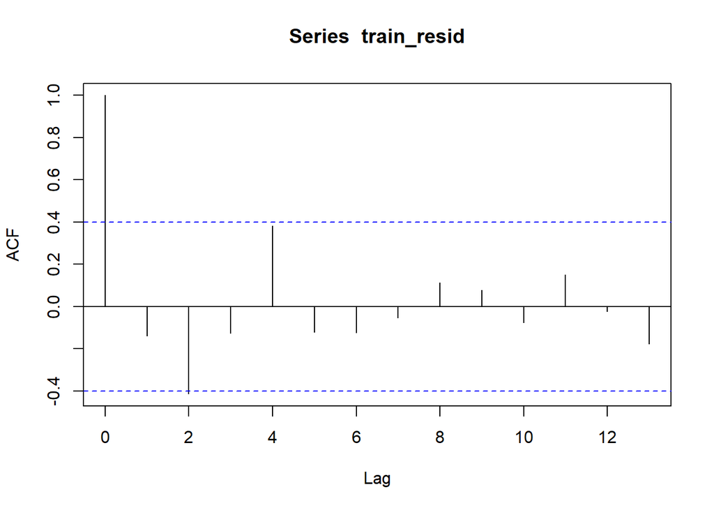

```r
acf(train_resid)
```

#### Test Error

```r
test_preds <- predict(mod2,test)
resid <- test$mpg - test_preds

mse <- mse(test$mpg , test_preds)
mae <- mae(test$mpg, test_preds)
mape <- mape(test$mpg, test_preds)

print(paste("Mean Squared Error is: ", round(mse,4)))
```

```
## [1] "Mean Squared Error is:  8.9878"
```

```r
print(paste("Mean Absolute Error is: ", round(mae,4)))
```

```
## [1] "Mean Absolute Error is:  2.1159"
```

```r
print(paste0("Mean Absolute Percentage Error is: ", round(mape*100,2), '%'))
```

```
## [1] "Mean Absolute Percentage Error is: 10.22%"
```

### Anova of All Mods

```r
anova(mod2, mod,test="Chisq")
```

```
## Analysis of Variance Table
##
## Model 1: mpg ~ wt + qsec
## Model 2: mpg ~ cyl + disp + hp + drat + wt + qsec + vs + am + gear + carb
##   Res.Df     RSS Df Sum of Sq Pr(>Chi)
## 1     21 106.482
## 2     13  61.795  8    44.687   0.3096
```